# 8.신경망모형

### 예제 1 nnet

iris 자료에 대해 신경망 모형을 적합한다.  
자료의 수는 150개이며 입력변수의 차원은 4이며, 목표값은 3개의 범주로 출력된다.

```r
library(nnet)
nn.iris <- nnet(Species~., data=iris,
                size=2,      # 은닉층의 노드 수(size)는 2
                rang=0.1,    # 초기 랜덤 가중치의 범위는 [-0.1, 0.1]
                decay=5e-4,  # weight decay 모수는 0(디폴트)
                maxit=200)   # 최대반복수는 200(디폴트는 100)
summary(nn.iris)
```

```
## a 4-2-3 network with 19 weights
## options were - softmax modelling  decay=5e-04
##  b->h1 i1->h1 i2->h1 i3->h1 i4->h1
##  -0.31  -0.68  -2.03   3.23   1.62
##  b->h2 i1->h2 i2->h2 i3->h2 i4->h2
##  24.02  10.13   9.92 -18.44 -15.63
##  b->o1 h1->o1 h2->o1
##   3.95 -10.09   6.47
##  b->o2 h1->o2 h2->o2
##  -5.99   6.97   8.16
##  b->o3 h1->o3 h2->o3
##   2.05   3.12 -14.62
```

위의 결과는 연결선의 방향과 가중치를 나타낸다.  
다만, 초깃값이 별도로 지정하지 않으면 nnet() 함수가 실행될 때 마다 결과가 달라질 것이다.

적합결과를 시각화 하면 다음과 같다.  
시각화를 위한 plot.nnet() 함수는 아래의 절차에 따라 불러올 수 있다.

```r
library(devtools)
```

```r
source_url('https://gist.githubusercontent.com/Peque/41a9e20d6687f2f3108d/raw/85e14f3a292e126f1454864427e3a189c2fe33f3/nnet_plot_update.r')
```

```
## i SHA-1 hash of file is bf3c7b8ac910823b729e3ce73bb6ab5e6955ad3d
```

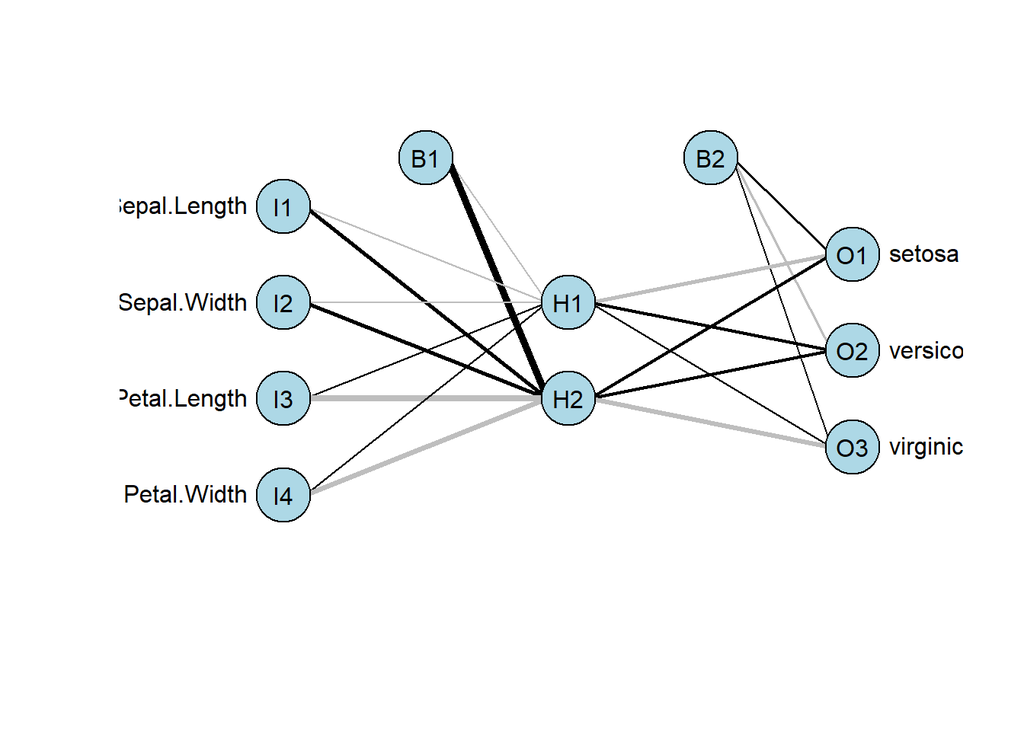

```r
plot.nnet(nn.iris)
```

```r
library(clusterGeneration)
```

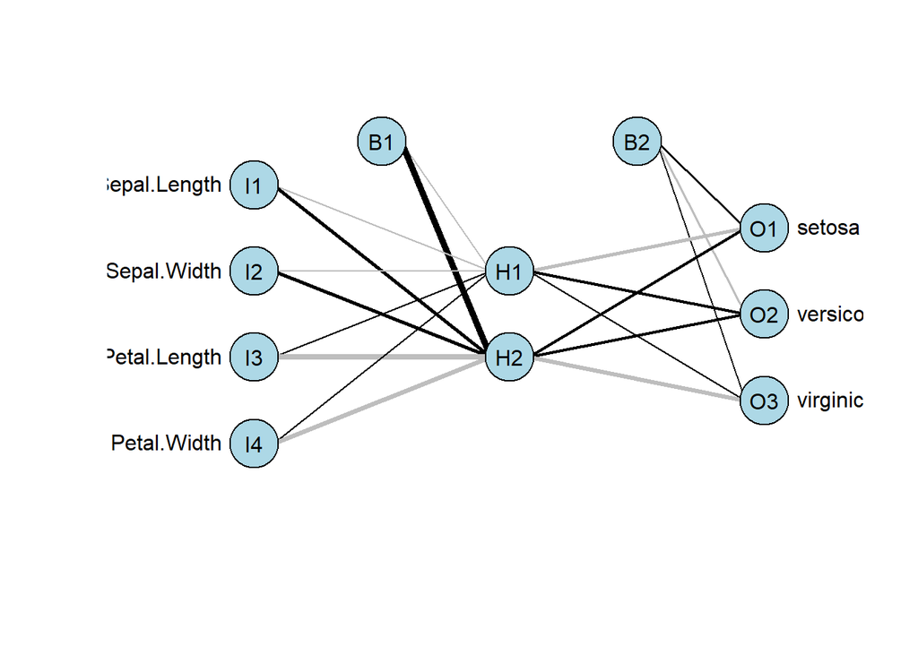

```r
library(scales)
library(reshape)
plot(nn.iris)
```

신경망 모형에 대한 정오분류표는 다음과 같다.

```r
table(iris$Species, predict(nn.iris, iris, type = "class"))
```

```
##
##              setosa versicolor virginica
##   setosa         50          0         0
##   versicolor      0         49         1
##   virginica       0          0        50
```

### 예제2 neuralnet

자료 infert는 자연유산과 인공유산 후의 불임에 대한 사례-대조 연구 자료로 8개의 변수와 248개의 관측치를 가지고 있다.  
반응변수 case는 (1:사례, 0:대조)를 나타낸다.

```r
data(infert, package="datasets")
str(infert)
```

```
## 'data.frame':    248 obs. of  8 variables:
##  $ education     : Factor w/ 3 levels "0-5yrs","6-11yrs",..: 1 1 1 1 2 2 2 2 2 2 ...
##  $ age           : num  26 42 39 34 35 36 23 32 21 28 ...
##  $ parity        : num  6 1 6 4 3 4 1 2 1 2 ...
##  $ induced       : num  1 1 2 2 1 2 0 0 0 0 ...
##  $ case          : num  1 1 1 1 1 1 1 1 1 1 ...
##  $ spontaneous   : num  2 0 0 0 1 1 0 0 1 0 ...
##  $ stratum       : int  1 2 3 4 5 6 7 8 9 10 ...
##  $ pooled.stratum: num  3 1 4 2 32 36 6 22 5 19 ...
```

```r
library(neuralnet)
net.infert <- neuralnet(case~age+parity+induced+spontaneous,
                        data=infert, hidden=2, err.fct="ce",
                        linear.output=FALSE, likelihood=TRUE)
# hidden= 은닉층의 노드 수. err.fct= 오차(error) 계산에 사용되는 미분가능 함수로 “sse”, “ce”(cross entropy) 지정 가능
net.infert
```

```
## $call
## neuralnet(formula = case ~ age + parity + induced + spontaneous,
##     data = infert, hidden = 2, err.fct = "ce", linear.output = FALSE,
##     likelihood = TRUE)
##
## $response
##     case
## 1      1
## 2      1
## 3      1
## 4      1
## 5      1
## 6      1
## 7      1
## 8      1
```

[output cut: 1342 more lines]

```r
plot(net.infert)
```

[output not shown]

neuralnet() 함수의 수행 결과의 추가적인 정보는 다음 과정을 통해 확인할 수 있다.

```r
names(net.infert)
```

```
##  [1] "call"                "response"            "covariate"
##  [4] "model.list"          "err.fct"             "act.fct"
##  [7] "linear.output"       "data"                "exclude"
## [10] "net.result"          "weights"             "generalized.weights"
## [13] "startweights"        "result.matrix"
```

이 가운데 결과 행렬에 대한 정보는 다음을 통해 확인할 수 있다.

```r
net.infert$result.matrix
```

```
##                                  [,1]
## error                    1.248993e+02
## reached.threshold        9.953017e-03
## steps                    1.681000e+03
## aic                      2.757985e+02
## bic                      3.214731e+02
## Intercept.to.1layhid1    1.266232e+00
## age.to.1layhid1         -1.537313e+00
## parity.to.1layhid1       6.269878e+00
## induced.to.1layhid1      1.722056e-01
## spontaneous.to.1layhid1 -1.655081e+02
## Intercept.to.1layhid2    5.543909e+00
## age.to.1layhid2         -1.135539e-01
## parity.to.1layhid2       1.683403e+00
## induced.to.1layhid2     -2.110149e+00
## spontaneous.to.1layhid2 -3.216976e+00
## Intercept.to.case        3.698624e+00
## 1layhid1.to.case        -3.881369e+01
## 1layhid2.to.case        -5.483170e+00
```

원 자료와 함께 적합값을 출력하는 절차는 다음과 같다.  
전체자료는 $data에 저장되어 있고,  
모형 적합에 사용된 자료는 $covariate과 $response를 통해 확인 가능 하며,  
적합값은 $net.result에 제공된다.

```r
out <- cbind(net.infert$covariate, net.infert$net.result[[1]])
dimnames(out) <- list(NULL, c("age","parity","induced","spontaneous", "nn-output"))
head(out)
```

```
##      age parity induced spontaneous nn-output
## [1,]  26      6       1           2 0.1545611
## [2,]  42      1       1           0 0.6189033
## [3,]  39      6       2           0 0.1443615
## [4,]  34      4       2           0 0.1540414
## [5,]  35      3       1           1 0.3535650
## [6,]  36      4       2           1 0.4929547
```

```r
head(net.infert$generalized.weights[[1]]) # 열은 4개의 입력변수
```

```
##              [,1]        [,2]       [,3]       [,4]
## [1,] 0.0095332463 -0.14132755 0.17715431 0.27007628
## [2,] 0.1510423244 -2.23915762 2.80678772 4.27901979
## [3,] 0.0005693881 -0.00844037 0.01057971 0.01613545
## [4,] 0.0090947336 -0.13482672 0.16900551 0.25765328
## [5,] 0.1052314390 -1.56002484 1.95549368 2.98120022
## [6,] 0.1355569092 -2.00959094 2.51902551 3.84031893
```

일반화가중치에 대한 시각화를 수행하면 다음과 같다.

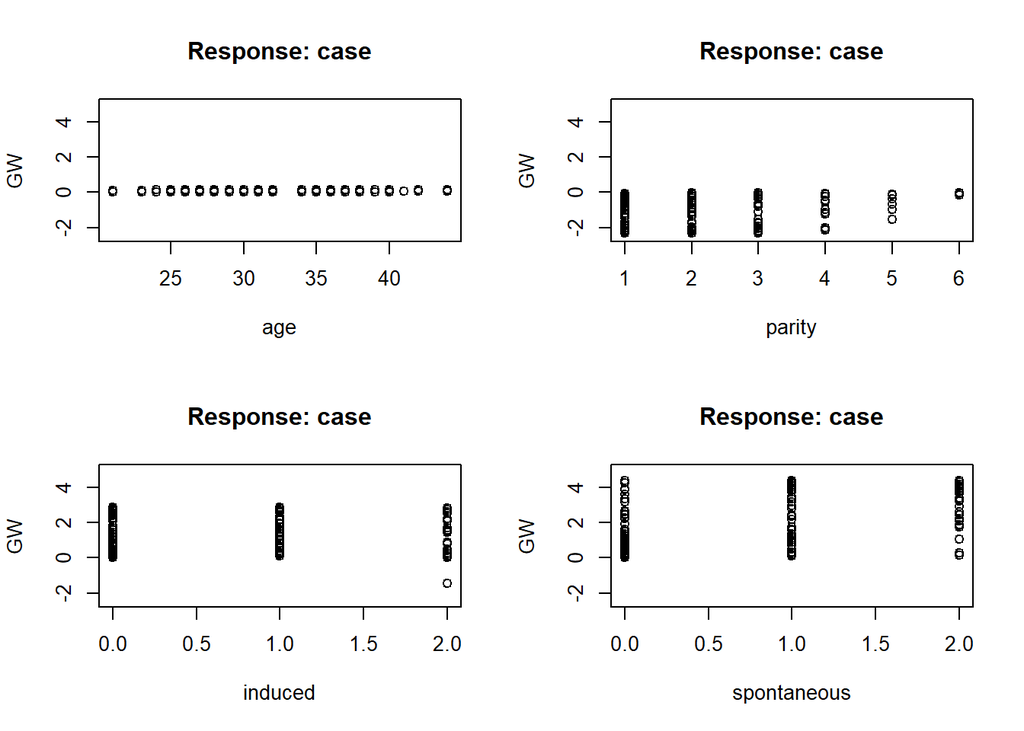

```r
par(mfrow=c(2,2))
gwplot(net.infert, selected.covariate="age", min=-2.5, max=5)
gwplot(net.infert, selected.covariate="parity", min=-2.5, max=5)
gwplot(net.infert, selected.covariate="induced", min=-2.5, max=5)
gwplot(net.infert, selected.covariate="spontaneous", min=-2.5, max=5)
```

```r
par(mfrow=c(1,1))
```

```r
new.output <- compute(net.infert,
                      covariate=matrix(c(22,1,0,0,
                                         22,1,1,0,
                                         22,1,0,1,
                                         22,1,1,1),
                                       byrow=TRUE, ncol=4))
new.output$net.result
```

```
##           [,1]
## [1,] 0.1497541
## [2,] 0.1959046
## [3,] 0.3112733
## [4,] 0.8523543
```

위의 결과(new.output$net.result)는 주어진 공변량 조합에 대한 예측 결과로,  
사전 낙태의 수에 따라 예측 확률이 증가함을 보여준다.

### 예제 3 neuralnet

0과 100 사이의 난수를 50개 발생시키고, 제곱근을 취한 값을 결과로 하는 자료를 구축한다.  
이 자료를 신경망으로 학습하여 새로운 자료에 대한 예측을 수행한다.  
set.seed() 함수를 이용하여 초깃값을 지정한 후 아래의 절차를 수행하면 일정한 결과를 얻을 수 있다.

```r
library(neuralnet)
train.input <- as.data.frame(runif(50, min=0, max=100))
train.output <- sqrt(train.input)
train.data <- cbind(train.input, train.output)
colnames(train.data) <- c("Input","Output")
head(train.data)
```

```
##      Input   Output
## 1 48.08699 6.934478
## 2 35.91632 5.993023
## 3 90.14414 9.494427
## 4 61.97406 7.872360
## 5 71.65888 8.465157
## 6 84.32102 9.182648
```

1개의 은닉층과 10개의 은닉노드를 가지는 신경망모형을 적합한다.  
threshold= 옵션은 오차 함수의 편미분에 대한 값으로 정지규칙으로 사용된다.

```r
net.sqrt <- neuralnet(Output~Input,train.data, hidden=10, threshold=0.01)
print(net.sqrt)
```

```
## $call
## neuralnet(formula = Output ~ Input, data = train.data, hidden = 10,
##     threshold = 0.01)
##
## $response
##       Output
## 1  6.9344784
## 2  5.9930230
## 3  9.4944267
## 4  7.8723602
## 5  8.4651565
## 6  9.1826478
## 7  0.9831174
## 8  5.5101569
## 9  9.2023642
```

[output cut: 383 more lines]

```r
plot(net.sqrt)
```

[output not shown]

몇 개의 검증용 자료에 대해 구축된 신경망 모형을 적용한다.  
1~10 정수값의 제곱을 취하여 검증용 자료(test.data)를 만든 후,  
이 자료에 대해 compute() 함수를 통해 신경망 모형 (net.sqrt)을 적용하고,  
그 결과를 출력한다.

```r
test.data <- as.data.frame((1:10)^2)
test.out <- compute(net.sqrt, test.data)
ls(test.out)
```

```
## [1] "net.result" "neurons"
```

```r
 print(test.out$net.result)
```

```
##            [,1]
##  [1,] 0.9994511
##  [2,] 1.9972922
##  [3,] 2.9987323
##  [4,] 4.0017269
##  [5,] 4.9969261
##  [6,] 6.0024536
##  [7,] 7.0035704
##  [8,] 7.9967385
##  [9,] 9.0034609
## [10,] 9.9889742
```

이제 은닉층이 2개인 모형을 적합해 보자.  
각각의 은닉 노드의 수는 10개, 8개로 한다. 이를 위해 neuralnet() 함수의 옵션을 hidden=c(10,8)으로 수정하여 위 과정을 실행한다.  
그 결과는 다음과 같다.

```r
net2.sqrt <- neuralnet(Output~Input,train.data, hidden=c(10,8), threshold=0.01)
plot(net2.sqrt)
```

[output not shown]

```r
test2.out <- compute(net2.sqrt, test.data)
print(test2.out$net.result)
```

```
##            [,1]
##  [1,] 0.9869799
##  [2,] 1.9228246
##  [3,] 3.0004631
##  [4,] 4.0035152
##  [5,] 4.9983474
##  [6,] 5.9976154
##  [7,] 7.0025200
##  [8,] 7.9998363
##  [9,] 8.9994577
## [10,] 9.9909770
```